# DATA6075ACode

Samantha Mesa

2026-10-03

## Approach

Does AM West’s better overall delay rate reflect truly better performance, or does Alaska’s lower delay rate in every city reveal that flight mix (Phoenix vs. Seattle) is misleading the overall comparison?

Potential challenges: The main challenges are getting the data in cleanly: commas in numbers like 1,841 need quoting, and you must keep the blank cells and separator row in the CSV, then remove that empty row before using fill(airline) so it doesn’t become a bogus record. During analysis, the biggest pitfall is averaging city percentages instead of dividing total delays by total flights, and you’ll also need to show each airline’s flight share by city to explain the reversal. Finally, make sure your R Markdown knits from a clean session (reading from the raw GitHub URL, not a local path) and includes written narrative after each table and chart, since the rubric grades your explanations as well as your code.

```r
library(tidyverse)
library(scales)
csv_url <- "https://raw.githubusercontent.com/Sampro24/DATA607Homeworks/refs/heads/main/AirlineDelays.csv"

raw <- tryCatch(
  read_csv(csv_url, col_types = cols(.default = col_character())),
  error = function(e) {
    message("GitHub URL not reachable, falling back to local file.")
    read_csv("airline_delays.csv", col_types = cols(.default = col_character()))
  }
)
raw
```

```
## # A tibble: 5 × 7
##   ...1    ...2    `Los Angeles` Phoenix `San Diego` `San Francisco` Seattle
##   <chr>   <chr>   <chr>         <chr>   <chr>       <chr>           <chr>
## 1 ALASKA  on time 497           221     212         503             1841
## 2 <NA>    delayed 62            12      20          102             305
## 3 <NA>    <NA>    <NA>          <NA>    <NA>        <NA>            <NA>
## 4 AM WEST on time 694           4840    383         320             201
## 5 <NA>    delayed 117           415     65          129             61
```

## 2. Tidying and transforming

```r
delays_long <- raw %>%
  rename(airline = 1, status = 2) %>%
  filter(!if_all(everything(), is.na)) %>%     # remove the blank separator row
  fill(airline) %>%                            # populate missing airline names
  pivot_longer(
    cols = -c(airline, status),
    names_to = "city",
    values_to = "flights"
  ) %>%
  mutate(
    flights = parse_number(flights),           # "1,841" -> 1841
    status  = str_trim(status)
  )

delays_long
```

```
## # A tibble: 20 × 4
##    airline status  city          flights
##    <chr>   <chr>   <chr>           <dbl>
##  1 ALASKA  on time Los Angeles       497
##  2 ALASKA  on time Phoenix           221
##  3 ALASKA  on time San Diego         212
##  4 ALASKA  on time San Francisco     503
##  5 ALASKA  on time Seattle          1841
##  6 ALASKA  delayed Los Angeles        62
##  7 ALASKA  delayed Phoenix            12
##  8 ALASKA  delayed San Diego          20
##  9 ALASKA  delayed San Francisco     102
## 10 ALASKA  delayed Seattle           305
## 11 AM WEST on time Los Angeles       694
## 12 AM WEST on time Phoenix          4840
## 13 AM WEST on time San Diego         383
## 14 AM WEST on time San Francisco     320
## 15 AM WEST on time Seattle           201
## 16 AM WEST delayed Los Angeles       117
## 17 AM WEST delayed Phoenix           415
## 18 AM WEST delayed San Diego          65
## 19 AM WEST delayed San Francisco     129
## 20 AM WEST delayed Seattle            61
```

```r
# sanity checks: no missing values, 2 airlines x 2 statuses x 5 cities = 20 rows
stopifnot(nrow(delays_long) == 20, !anyNA(delays_long))
```

For analysis, a “one row per airline and city” layout is easiest, with columns for on-time and delayed counts and the total.

```r
by_city <- delays_long %>%
  pivot_wider(names_from = status, values_from = flights) %>%
  rename(on_time = `on time`) %>%
  mutate(
    total      = on_time + delayed,
    delay_rate = delayed / total,
    ontime_rate = on_time / total
  )

by_city
```

```
## # A tibble: 10 × 7
##    airline city          on_time delayed total delay_rate ontime_rate
##    <chr>   <chr>           <dbl>   <dbl> <dbl>      <dbl>       <dbl>
##  1 ALASKA  Los Angeles       497      62   559     0.111        0.889
##  2 ALASKA  Phoenix           221      12   233     0.0515       0.948
##  3 ALASKA  San Diego         212      20   232     0.0862       0.914
##  4 ALASKA  San Francisco     503     102   605     0.169        0.831
##  5 ALASKA  Seattle          1841     305  2146     0.142        0.858
##  6 AM WEST Los Angeles       694     117   811     0.144        0.856
##  7 AM WEST Phoenix          4840     415  5255     0.0790       0.921
##  8 AM WEST San Diego         383      65   448     0.145        0.855
##  9 AM WEST San Francisco     320     129   449     0.287        0.713
## 10 AM WEST Seattle           201      61   262     0.233        0.767
```

## 3. Count analysis

First, plain counts of flights by airline and status.

```r
delays_long %>%
  group_by(airline, status) %>%
  summarise(flights = sum(flights), .groups = "drop") %>%
  pivot_wider(names_from = status, values_from = flights)
```

```
## # A tibble: 2 × 3
##   airline delayed `on time`
##   <chr>     <dbl>     <dbl>
## 1 ALASKA      501      3274
## 2 AM WEST     787      6438
```

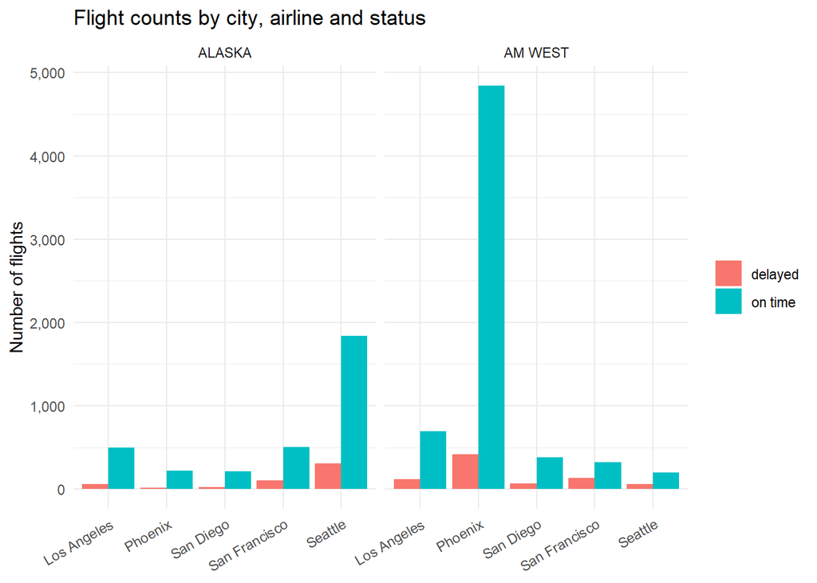

```r
ggplot(delays_long, aes(x = city, y = flights, fill = status)) +
  geom_col(position = "dodge") +
  facet_wrap(~ airline) +
  scale_y_continuous(labels = comma) +
  labs(title = "Flight counts by city, airline and status",
       x = NULL, y = "Number of flights", fill = NULL) +
  theme_minimal() +
  theme(axis.text.x = element_text(angle = 30, hjust = 1))
```

Counts alone are hard to compare. AM West flies about 7,200 flights versus Alaska’s roughly 3,800, and the volumes are very uneven across cities (AM West has over 5,000 flights into Phoenix, Alaska over 2,000 into Seattle). That is why percentages are needed.

## 4. Overall comparison (percentages)

Overall delay rate = total delayed flights / total flights. I divide the totals rather than averaging the five city percentages, because averaging percentages would give small cities the same weight as large ones.

```r
overall <- by_city %>%
  group_by(airline) %>%
  summarise(
    on_time = sum(on_time),
    delayed = sum(delayed),
    total   = sum(total),
    delay_rate = delayed / total,
    .groups = "drop"
  )

overall %>%
  mutate(delay_rate = percent(delay_rate, accuracy = 0.1))
```

```
## # A tibble: 2 × 5
##   airline on_time delayed total delay_rate
##   <chr>     <dbl>   <dbl> <dbl> <chr>
## 1 ALASKA     3274     501  3775 13.3%
## 2 AM WEST    6438     787  7225 10.9%
```

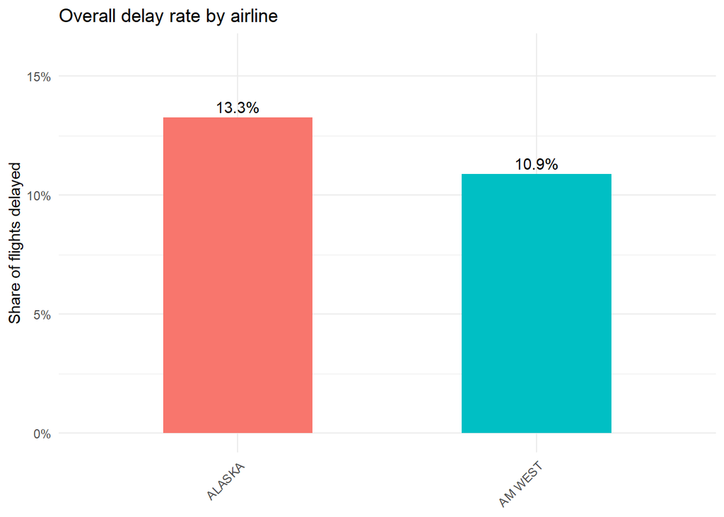

```r
ggplot(overall, aes(x = airline, y = delay_rate, fill = airline)) +
  geom_col(width = 0.5, show.legend = FALSE) +
  geom_text(aes(label = percent(delay_rate, accuracy = 0.1)), vjust = -0.4) +
  scale_y_continuous(labels = percent, limits = c(0, 0.16)) +
  labs(title = "Overall delay rate by airline", x = NULL, y = "Share of flights delayed") +
  theme_minimal()+
  theme(axis.text.x = element_text(angle = 45, hjust = 1))
```

**Finding:** Overall, Alaska delays about **13.3%** of its flights and AM West about **10.9%**. Taken at face value, AM West looks better by roughly 2.4 percentage points.

## 5. City-by-city comparison (percentages)

```r
city_compare <- by_city %>%
  select(airline, city, delay_rate) %>%
  pivot_wider(names_from = airline, values_from = delay_rate) %>%
  mutate(difference = `AM WEST` - ALASKA,
         better = if_else(ALASKA < `AM WEST`, "Alaska", "AM West"))

city_compare %>%
  mutate(across(c(ALASKA, `AM WEST`, difference), ~ percent(.x, accuracy = 0.1)))
```

```
## # A tibble: 5 × 5
##   city          ALASKA `AM WEST` difference better
##   <chr>         <chr>  <chr>     <chr>      <chr>
## 1 Los Angeles   11.1%  14.4%     3.3%       Alaska
## 2 Phoenix       5.2%   7.9%      2.7%       Alaska
## 3 San Diego     8.6%   14.5%     5.9%       Alaska
## 4 San Francisco 16.9%  28.7%     11.9%      Alaska
## 5 Seattle       14.2%  23.3%     9.1%       Alaska
```

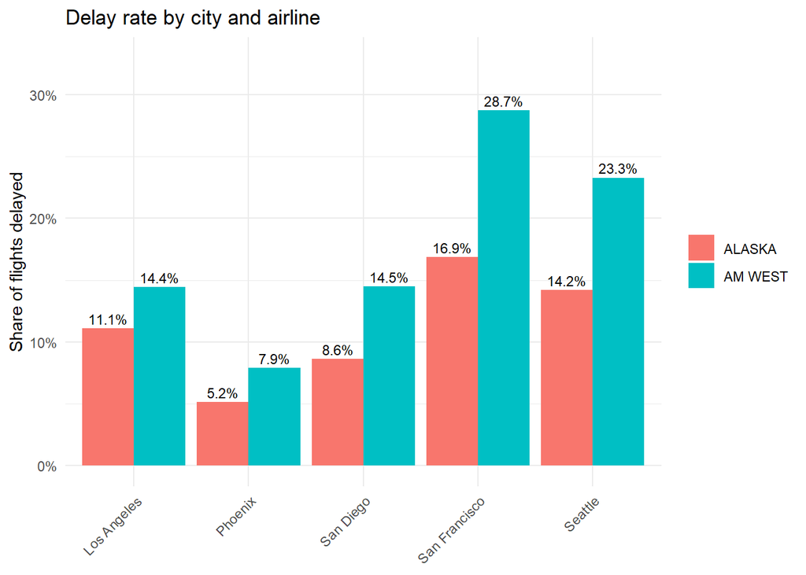

```r
ggplot(by_city, aes(x = city, y = delay_rate, fill = airline)) +
  geom_col(position = "dodge") +
  geom_text(aes(label = percent(delay_rate, accuracy = 0.1)),
            position = position_dodge(width = 0.9), vjust = -0.4, size = 3) +
  scale_y_continuous(labels = percent, limits = c(0, 0.33)) +
  labs(title = "Delay rate by city and airline",
       x = NULL, y = "Share of flights delayed", fill = NULL) +
  theme_minimal()+
  theme(axis.text.x = element_text(angle = 45, hjust = 1))
```

**Finding:** Alaska has the **lower delay rate in all five cities**. The gap is smallest in Phoenix and largest in San Francisco, where AM West delays about 29% of flights against Alaska’s 17%. This is the reverse of the overall result.

## 6. Explaining the discrepancy

How can AM West be better overall but worse in every city? The answer is **flight mix** (Simpson’s paradox). Delay rates differ a lot by city for both airlines: Phoenix is easy (low delays), Seattle and San Francisco are hard (high delays). The two airlines concentrate their flights in different cities.

```r
mix <- by_city %>%
  group_by(airline) %>%
  mutate(share_of_airline = total / sum(total)) %>%
  ungroup()

mix %>%
  select(airline, city, total, share_of_airline) %>%
  mutate(share_of_airline = percent(share_of_airline, accuracy = 0.1)) %>%
  pivot_wider(names_from = airline, values_from = c(total, share_of_airline))
```

```
## # A tibble: 5 × 5
##   city          total_ALASKA `total_AM WEST` share_of_airline_ALASKA
##   <chr>                <dbl>           <dbl> <chr>
## 1 Los Angeles            559             811 14.8%
## 2 Phoenix                233            5255 6.2%
## 3 San Diego              232             448 6.1%
## 4 San Francisco          605             449 16.0%
## 5 Seattle               2146             262 56.8%
## # ℹ 1 more variable: `share_of_airline_AM WEST` <chr>
```

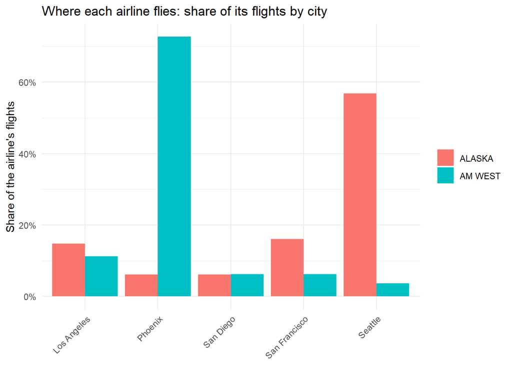

```r
ggplot(mix, aes(x = city, y = share_of_airline, fill = airline)) +
  geom_col(position = "dodge") +
  scale_y_continuous(labels = percent) +
  labs(title = "Where each airline flies: share of its flights by city",
       x = NULL, y = "Share of the airline's flights", fill = NULL) +
  theme_minimal() +
  theme(axis.text.x = element_text(angle = 45, hjust = 1))
```

About **73%** of AM West’s flights go to Phoenix, the city with the lowest delay rates for both airlines. About **57%** of Alaska’s flights go to Seattle, where delays are much more common. So AM West’s overall number is dominated by its easy Phoenix flights, while Alaska’s is dragged up by Seattle. A quick check makes this concrete: if AM West had Alaska’s city mix, its delay rate would be higher than Alaska’s.

```r
am_rates <- by_city %>% filter(airline == "AM WEST") %>% select(city, delay_rate)
ak_mix   <- mix %>% filter(airline == "ALASKA") %>% select(city, share_of_airline)

reweighted <- inner_join(am_rates, ak_mix, by = "city") %>%
  summarise(am_west_with_alaska_mix = sum(delay_rate * share_of_airline))

tibble(
  `Alaska actual` = overall$delay_rate[overall$airline == "ALASKA"],
  `AM West actual` = overall$delay_rate[overall$airline == "AM WEST"],
  `AM West with Alaska's city mix` = reweighted$am_west_with_alaska_mix
) %>%
  mutate(across(everything(), ~ percent(.x, accuracy = 0.1)))
```

```
## # A tibble: 1 × 3
##   `Alaska actual` `AM West actual` `AM West with Alaska's city mix`
##   <chr>           <chr>            <chr>
## 1 13.3%           10.9%            21.4%
```

## 7. Conclusions

Overall, AM West is the more punctual airline with 10.9% of flights delayed compared with 13.3% for Alaska. But that picture reverses city by city: In all five cities, Alaska has the lower delay rate. The reversal comes down to flight mix. For AM West, about 73% of its flights are to Phoenix, where delays are infrequent for both carriers, and about 57% of Alaska’s are to Seattle, where delays are much more common. Thus, AM West’s average is pulled down by its soft Phoenix flights, and Alaska’s is pulled up by Seattle. The total figure isn’t a fair like-for-like measure because it compares airlines operating on different routes. The city-level comparison matters to a traveler choosing an airline for a particular route. The overall figure is not a fair like-for-like measure as it compares airlines flying different routes. For a traveler choosing between airlines on a particular route, however, the relevant comparison is at the city level, and by that measure Alaska is the more punctual airline. These results are limited to five cities and show only whether a flight was delayed, as the data do not include delay length, time of year, or weather.